# Lab 1: Intro to Bayesian model estimation: GLMs

Ben Goldstein and Krishna Pacifici

Fall 2024

## Load the data: Beetle counts

In this example, ecologists have surveyed a number of random plots around a volcano in New Zealand for beetles. We want to know how the count of beetles observed is related to altitude.

```r
beetle_data <- EcoData::volcanoisland
```

Let’s look at the histogram of counts.

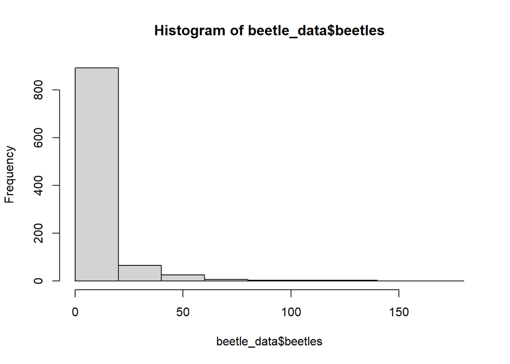

```r
hist(beetle_data$beetles)
```

We can look at histograms of other columns, too.

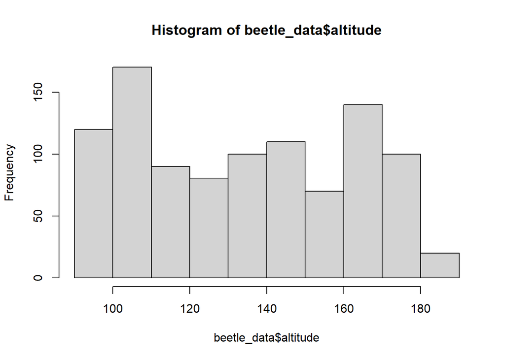

```r
# Altitude:
hist(beetle_data$altitude)
```

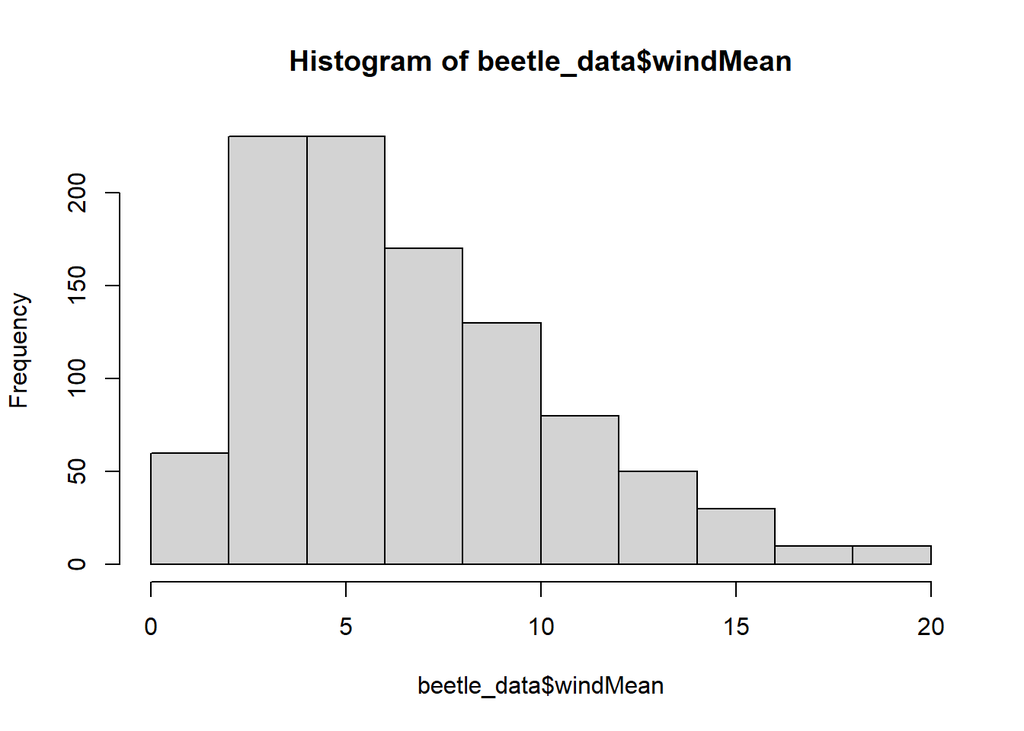

```r
# Mean wind speed:
hist(beetle_data$windMean)
```

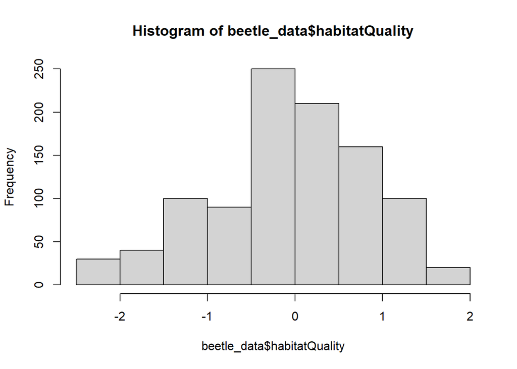

```r
# Habitat quality measure:
hist(beetle_data$habitatQuality)
```

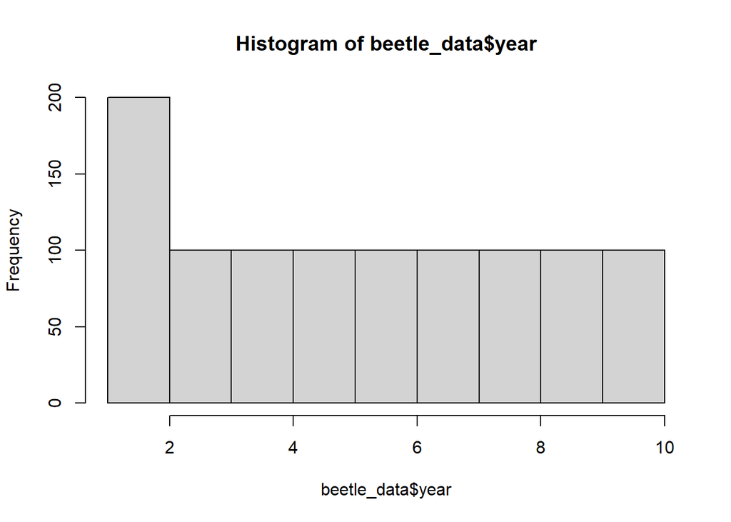

```r
# Year:
hist(beetle_data$year)
```

We can also plot beetle counts against different variables.

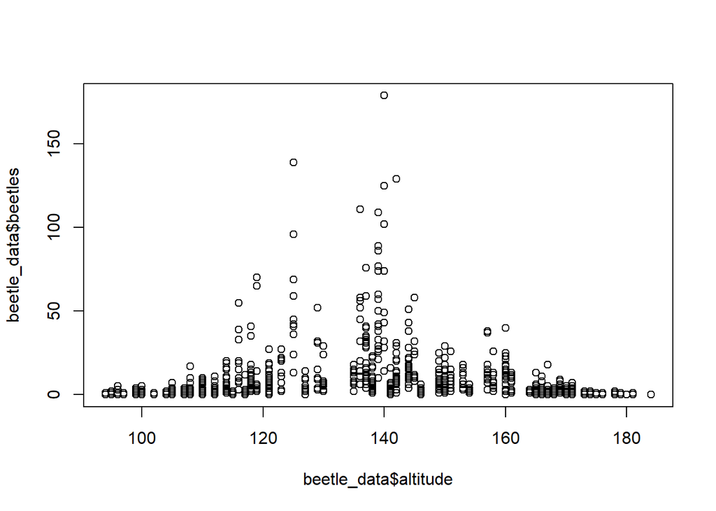

```r
plot(beetle_data$altitude, beetle_data$beetles)
```

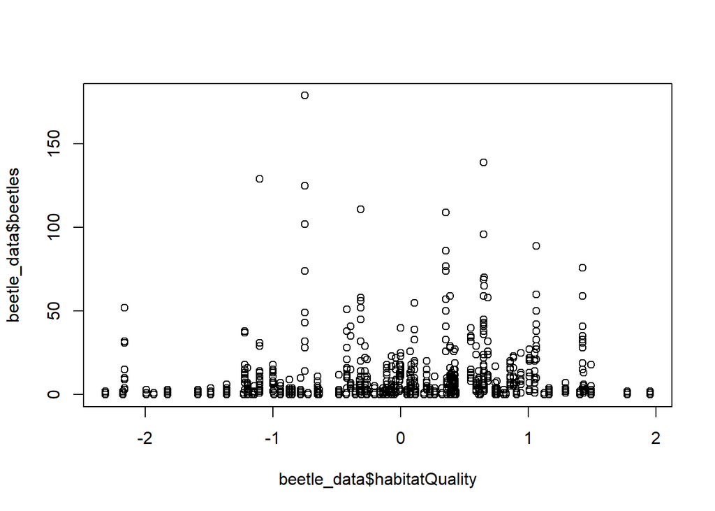

```r
plot(beetle_data$habitatQuality, beetle_data$beetles)
```

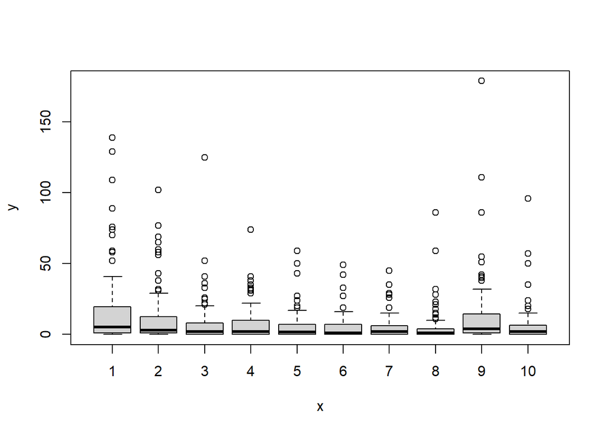

```r
# Make year a factor so we get boxplots
plot(as.factor(beetle_data$year), beetle_data$beetles)
```

**What do you notice from looking at these plots?**

Before we provide it to the model, we want to *center and scale* altitude, our variable of interest.

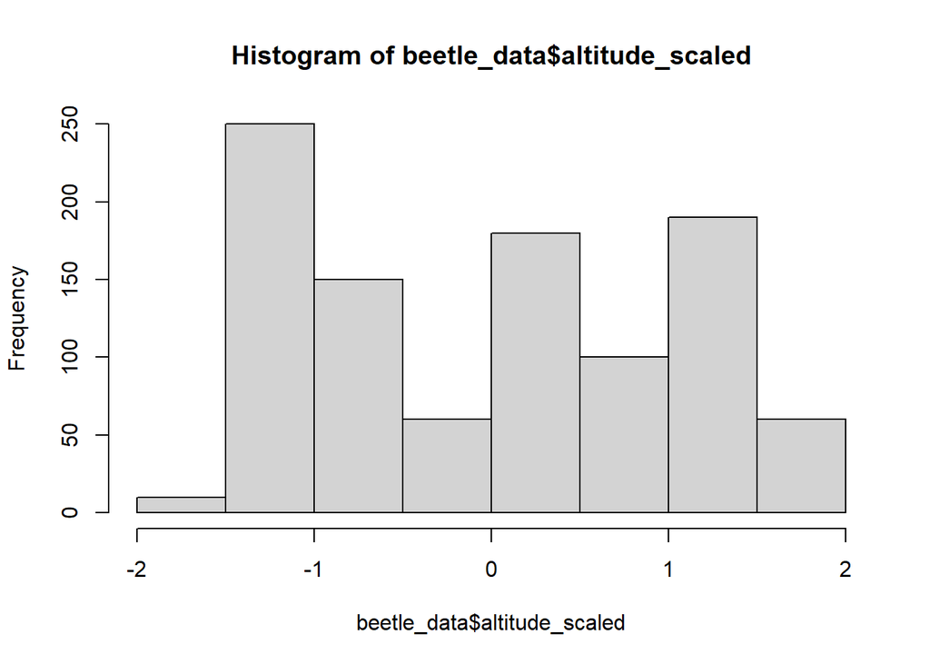

```r
beetle_data$altitude_scaled <- as.numeric(scale(beetle_data$altitude))

# Store the mean and sd of the originals so we can back-transform later
altitude_mean <- mean(beetle_data$altitude)
altitude_sd   <- sd(beetle_data$altitude)

hist(beetle_data$altitude_scaled)
```

### Model 1: beetles and altitude

We will start by estimating a simple GLM with one covariate on the mean abundance of beetles. Since our response variable is a count, the Poisson error family is appropriate. The model we’ll estimate is of the form:

$$y_i \sim
\text{Poisson}(\lambda_i)$$
$$\log(\lambda_i) = \beta_0 + \beta_1 \times
\text{altitude}_i$$
### Estiamting the model with MLE (Frequentist)

Estimating a GLM with frequentist tools is pretty straightforward. We tend to use out-of-the-box model estimators. In this case, we can just use the `glm` function provided by R. The code looks like the following:

```r
fit <- glm(formula = beetles ~ altitude_scaled,
           data = beetle_data,
           family = poisson(link = "log"))
summary(fit)
```

```
##
## Call:
## glm(formula = beetles ~ altitude_scaled, family = poisson(link = "log"),
##     data = beetle_data)
##
## Coefficients:
##                 Estimate Std. Error z value Pr(>|z|)
## (Intercept)      2.10279    0.01106 190.172  < 2e-16 ***
## altitude_scaled  0.04946    0.01103   4.485  7.3e-06 ***
## ---
## Signif. codes:  0 '***' 0.001 '**' 0.01 '*' 0.05 '.' 0.1 ' ' 1
##
## (Dispersion parameter for poisson family taken to be 1)
##
##     Null deviance: 18004  on 999  degrees of freedom
## Residual deviance: 17984  on 998  degrees of freedom
## AIC: 20506
##
## Number of Fisher Scoring iterations: 6
```

### Estimating the model with MCMC (Bayesian)

Next, let’s estimate this modeling using NIMBLE. For this model, this is overkill, but it’s a good place to start for understanding

#### Define the model code

The first step is to define model code.

```r
library(nimble)
my_code <- nimbleCode({

  # Data likelihood
  for (i in 1:nobs) {
    log(mu[i]) <- beta0 + beta1 * altitude[i]
    y[i] ~ dpois(mu[i])
  }

  # Priors for our two parameters
  beta0 ~ dnorm(0, sd = 10)
  beta1 ~ dnorm(0, sd = 10)
})
```

**What do these priors for `beta0` and `beta1` mean?**

**Do we need a prior for `mu`?**

**How do you know if a parameter needs priors to be specified?**

#### Build and compile the model

The next step is to construct a model object using the definition we just created. At this step, we populate the values for the data and build out the structure.

When you build a nimbleModel, there are four things you need to provide:

1. The model code
2. A list of **data**. Data are observations in the model that are allowed to change or be updated later on.
3. A list of **constants**. Constants are any quantities that aren’t going to change. Quantities that define the dimensions of model structure, such as for-loop indices or vector lengths, MUST be provided as constants. Other things like covariate data can often be provided as either constants or data.
4. A list of **initial values**. These are provided for parameters not specified in data/constants and not determined by other quantities in the model. Providing initial values is not strictly required but it’s almost always a good idea.

```r
my_model <- nimbleModel(
  code = my_code,
  data = list(
    altitude = beetle_data$altitude_scaled,
    y = beetle_data$beetles
  ),
  constants = list(
    nobs = nrow(beetle_data)
  ),
  inits = list(
    beta0 = 0,
    beta1 = 1
  )
)
```

```
## Defining model
```

```
## Building model
```

```
## Setting data and initial values
```

```
## Running calculate on model
##   [Note] Any error reports that follow may simply reflect missing values in model variables.
```

```
## Checking model sizes and dimensions
```

#### Run the MCMC algorithm to estimate the parameters

Now we can use NIMBLE’s built-in MCMC algorithm to obtain samples from the posterior distributions of `beta0` and `beta1`.

```r
mcmcConf <- configureMCMC(my_model)
```

```
## ===== Monitors =====
## thin = 1: beta0, beta1
## ===== Samplers =====
## RW sampler (2)
##   - beta0
##   - beta1
```

```r
mcmc <- buildMCMC(mcmcConf)
compiled_list <- compileNimble(my_model, mcmc)
```

```
## Compiling
##   [Note] This may take a minute.
##   [Note] Use 'showCompilerOutput = TRUE' to see C++ compilation details.
```

```r
samples <- runMCMC(compiled_list$mcmc, niter = 10000, nburnin = 2000,
                   thin = 1, nchains = 3, samplesAsCodaMCMC = TRUE)
```

```
## running chain 1...
```

```
## |-------------|-------------|-------------|-------------|
## |-------------------------------------------------------|
```

```
## running chain 2...
```

```
## |-------------|-------------|-------------|-------------|
## |-------------------------------------------------------|
```

```
## running chain 3...
```

```
## |-------------|-------------|-------------|-------------|
## |-------------------------------------------------------|
```

> Note: a “model” is a structure that specifies how a number of quantites are statistically related. Some of those quantites are “parameters” that aren’t observed and that we want to estimate. MCMC is an algorithm used to estimate the parameters in a model.

I like to use `MCMCvis` to make summaries of my posterior distributions.

```r
summary <- MCMCvis::MCMCsummary(samples)

summary
```

```
##             mean         sd       2.5%       50%      97.5% Rhat n.eff
## beta0 2.10263751 0.01118779 2.08069684 2.1027760 2.12479067    1  5565
## beta1 0.04955322 0.01101403 0.02810226 0.0494753 0.07145231    1  5377
```

The output has the following columns:

- `mean`: the mean of the posterior samples drawn for the variable
- `sd`: the standard deviation of the posterior samples drawn for the variable
- `2.5%`, `50%`, `97.5%`: the 2.5th, 50th, and 97.5th quantile of the posterior samples drawn for the variable
- `Rhat`: Also called the Gelman-Rubin diagnostic. This value is meant to represent how close well mixed your samples are. Broadly speaking, it tells you how much each of your chains moved around relative to differences between the chains—a well-mixed posterior sample should have mean values for each chain that are close together compared to the amount of mixing each chain is doing. Rhat is always $\geq$ 1. The rule of thumb is that an R-hat value of $\leq$ 1.1 is sufficient.
- `n.eff`: Number of effective samples. This value is an approximation of how many truly independent samples from the posterior distribution would have the same amount of information as your (Markovian, i.e. non-independent) posterior samples. Larger is better.

> Note: Measures of model convergence like `Rhat` and `n.eff` are NEVER measures of model goodness-of-fit or model performance. They are completely different. Very poorly fitting models can converge well. Instead, these are diagnostics that let you know whether your MCMC algorithm functioned sufficiently that your samples adequately represent the joint posterior distribution of your model parameters.

We can also visualize traceplots of our parameters using `plot()`.

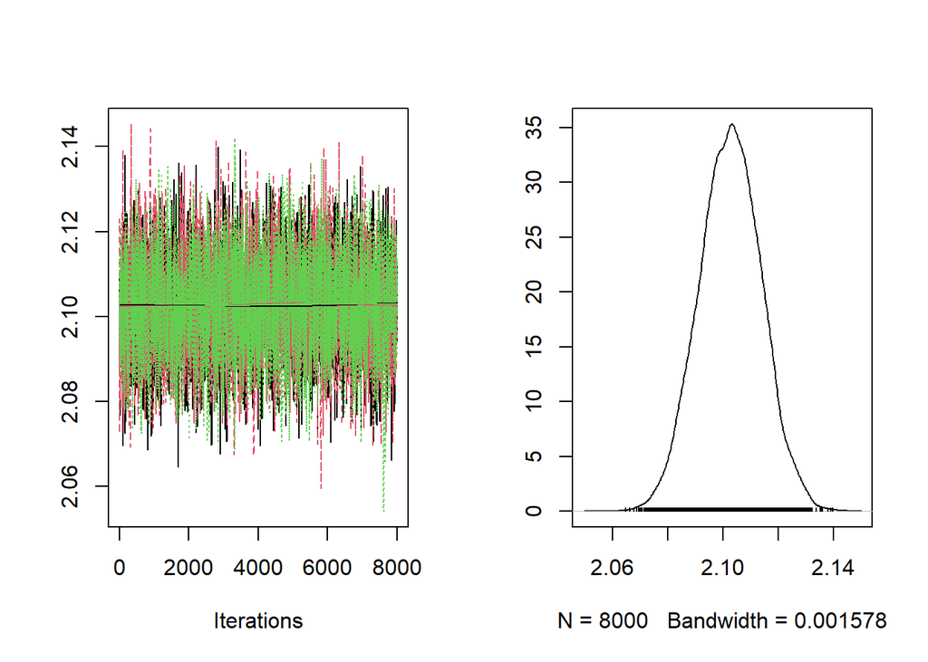

```r
plot(samples[, 1])
```

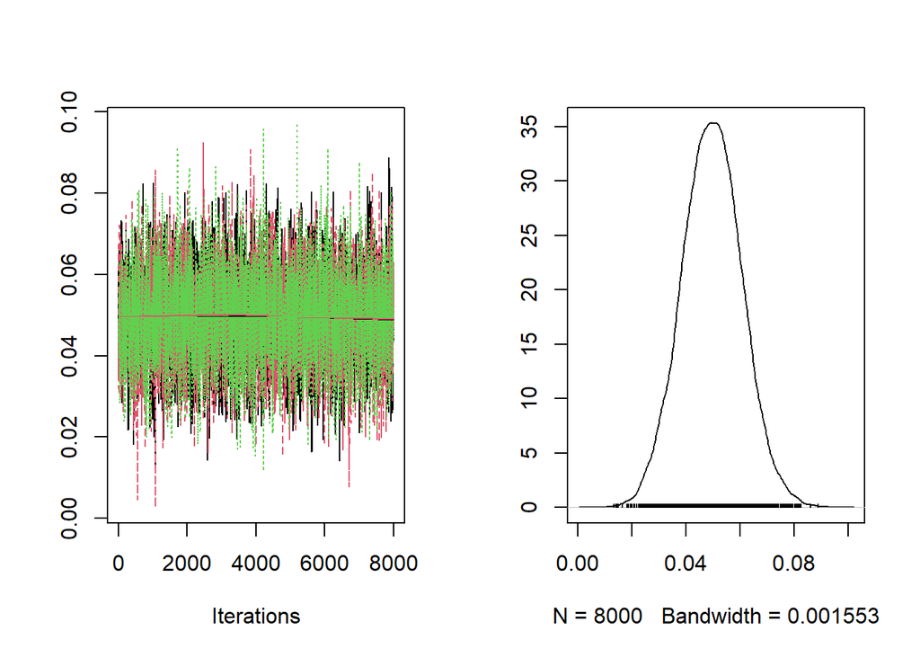

```r
plot(samples[, 2])
```

**Based on these traceplots and the model diagnostics from the summary, has the model converged?**

#### Compare MLE vs. MCMC estimates

```r
# Comparing MLE and Bayesian results
# MLE estimates
summary(fit)
```

```
##
## Call:
## glm(formula = beetles ~ altitude_scaled, family = poisson(link = "log"),
##     data = beetle_data)
##
## Coefficients:
##                 Estimate Std. Error z value Pr(>|z|)
## (Intercept)      2.10279    0.01106 190.172  < 2e-16 ***
## altitude_scaled  0.04946    0.01103   4.485  7.3e-06 ***
## ---
## Signif. codes:  0 '***' 0.001 '**' 0.01 '*' 0.05 '.' 0.1 ' ' 1
##
## (Dispersion parameter for poisson family taken to be 1)
##
##     Null deviance: 18004  on 999  degrees of freedom
## Residual deviance: 17984  on 998  degrees of freedom
## AIC: 20506
##
## Number of Fisher Scoring iterations: 6
```

```r
# Bayesian estimates
summary[, 1]
```

```
## [1] 2.10263751 0.04955322
```

#### Posterior predictive sampling

Since we’re out of the world of linear models, interpreting the beta estimates is a little harder. Next, let’s use our Bayesian model to predict counts of beetles at different altitudes.

We’ll do this by directly working with the posterior samples we saved from our MCMC run. For a given altitude, we can directly calculate the expected abundance according to the model equation
$$\log(\lambda) = \beta_0 + \beta_1 \times
\text{altitude}$$
, plugging in each of our samples of $\beta_0$ and $\beta_1$. Then, the resulting set of values of $\lambda$ is your approximate posterior distribution.

Make sure that if you scaled your variables before estimating the model that you provide new altitudes on the same scale!

[figure not shown]

```r
beetle_abund_pred <- data.frame(
  altitude = seq(-2, 2, length.out = 13),
  mean = NA, Q025 = NA, Q095 = NA
)

# Chains don't matter here, so we combine all samples into a matrix:
samples_mtx <- as.matrix(samples)
# Make a matrix where each row is a MCMC iteration and each column is an altitude
lambda_mtx <- matrix(NA, nrow = nrow(samples_mtx), ncol = nrow(beetle_abund_pred))

# Loop over posterior samples and calculate expected abundance
for (i in 1:nrow(lambda_mtx)) {
  lambda_mtx[i, ] <- exp(samples_mtx[i, "beta0"] +
                         samples_mtx[i, "beta1"] * beetle_abund_pred$altitude)
}

# Summarize posteriors
beetle_abund_pred$mean <- colMeans(lambda_mtx)
beetle_abund_pred$Q025 <- apply(lambda_mtx, 2, quantile, probs = 0.025)
beetle_abund_pred$Q975 <- apply(lambda_mtx, 2, quantile, probs = 0.975)

# Back-transform altitude to the correct scale
beetle_abund_pred$altitude_unscaled <-
          beetle_abund_pred$altitude * altitude_sd + altitude_mean

# Plot the output
library(ggplot2)
ggplot(beetle_abund_pred, aes(altitude, mean, ymin = Q025, ymax = Q975)) +
  geom_ribbon(alpha = 0.3) +
  geom_line() +
  theme_minimal() + xlab("Altitude (m)") + ylab("Expected count of beetles")
```

### Exercise: modify the covariates in the model

Bear in mind that for this model, we’ve assumed that the log of the expected count of beetles is linearly related to altitude. While that assumption doesn’t produce a linear prediction of beetle counts (because of the link function), the curve is still constrained just like in a linear model.

However, in our exploratory analysis, it looked like beetles might have an optimum altitude at which they can be found. An optimum can be represented simply with a quadratic effect of the variable (think of the shape of the equation $y=-x^2$).

*Exercise:* Modify the code from the preceding example to estimate a quadratic effect of altitude on beetle abundance. The model you want to estimate is defined by these equations:

$$y_i \sim
\text{Poisson}(\lambda_i)$$
$$\log(\lambda_i) = \beta_0 + \beta_1 \times
\text{altitude}_i + \beta_2 \times (\text{altitude}_i)^2$$

You’ll want to start from the initial step by defining new `nimbleCode`.

```r
# Work here:
```